# Project01

##### 1 - Qual é a nossa variável independente? Qual é a nossa variável dependente?

São variáveis idenpendete são os teste congruente e incongruente. Variável dependente é o tempo de leitura gasto nos testes congruentes e incongruentes.

#### 2.

##### Qual seria um conjunto apropriado de hipóteses para essa tarefa?

Hipótese nula (H0): Não há diferença entre as velocidade de leitura com os grupos congruentes e incongruentes.

Hipótese alternativa H1: Existe diferença entre as velocidades de leituras com os grupos congruentes e incongruentes.

##### Que tipo de teste estatístico você espera executar?

Teste de comparação de médias

###### Justifique.

- Eu escolhi o teste T pareado, pois os grupos são relacionados (a mesma pessoa participou de ambos os grupos).
- Pois ele é indicado para comparar dois grupos com a amostra relacionais (a mesma pessoa aplicou nos dois testes).

```python
import pandas as pd
import scipy.stats

%matplotlib inline

data = pd.read_csv('stroopdata.csv')
data.head()

p_value = scipy.stats.ttest_rel(data.Congruent, data.Incongruent).pvalue
```

##### 3 - Reporte alguma estatística descritiva em relação a esse conjunto de dados. Inclua, pelo menos, uma medida de tendência central de pelo menos uma medida de variabilidade.

Estatística descritiva:

Medida de tendência central: congruente = 14.051125 incongruente = 22.015917

Variabilidade: Desvio padrão: Congruente = 3.559358 Incongruente = 4.797057

```python
data.describe()
```

|  | Congruent | Incongruent |
| --- | --- | --- |
| count | 24.000000 | 24.000000 |
| mean | 14.051125 | 22.015917 |
| std | 3.559358 | 4.797057 |
| min | 8.630000 | 15.687000 |
| 25% | 11.895250 | 18.716750 |
| 50% | 14.356500 | 21.017500 |
| 75% | 16.200750 | 24.051500 |
| max | 22.328000 | 35.255000 |

##### 4 - Forneça uma ou duas visualizações que mostre a distribuição da amostra de dados. Escreva uma ou duas sentenças sobre o que você observou do gráfico ou gráficos.

Maiorias das pessoas do teste congruente demorou em torno de 14 e os incongruentes em torno de 21. Também existe uma dispersão muito grande que vai de de 9 a 22 min para os congruentes e 15 a 35.

```
array([[<matplotlib.axes._subplots.AxesSubplot object at 0x107faeda0>,
        <matplotlib.axes._subplots.AxesSubplot object at 0x108043f60>]], dtype=object)
```

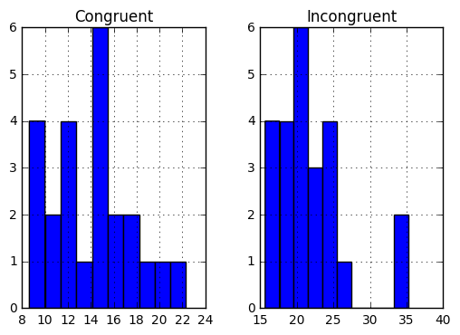

```python
data.hist()
```

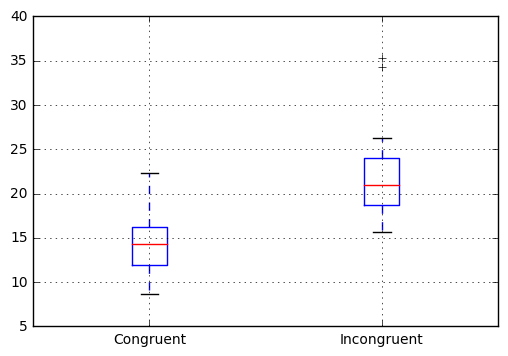

```python
data.boxplot()
```

##### 5 - Agora desempenhe o teste estatístico e reporte seus resultados. Qual seu nível de confiança e o valor estatístico crítico? Você rejeitou a hipótese nula ou falhou ao tentar rejeitá-la? Encontre uma conclusão em relação ao experimento da tarefa. Os resultados estão de acordo com suas expectativas?

Valor de nível de confiança é de 95% onde o valor estatístico crítico é de 5%.

```python
p_value
```

```
4.1030005857111781e-08
```

A hipótose nula foi rejeitada, pois de acordo com o teste T pareado existe menos de 5% de probabilidade do resultado ter ocorrido por acaso.

Visualizando o boxplot era de esperar que houvesse uma diferença entre os grupos.

##### 6 -O que você acha que é responsável pelo efeito observado? Consegue pensar em uma alternativa ou tarefa similar que resultaria em um efeito parecido?

O responsável pelo efeito é a forma de como as palavras fora apresentadas, no grupo incongruente existe uma confunsão do cerébro para dizer a cor e não a palavra apresentada, aumentando o tempo de leitura.

Um teste que poderia levar o efeito similar seria pedir para que os participantes lessem uma palavra de trás para frente.